# Psych841: HW 4

Joseph Austerweil

11/27/2020

```r
library(tidyverse)
```

```r
library(ggplot2)
library(dplyr)
```

## Monte Carlo and Markov Chain Monte Carlo

In this problem, you will compare two Monte Carlo methods for estimating the probability that a standard normal distribution has a value greater than two (i.e., $P(Y > 2 | Y \sim N(0,1))$). For all parts of Problem 1, we will use $T=1000$.

### 1. (a) Naive Monte Carlo

The first method we will use is naive Monte Carlo. Monte Carlo estimates the expected value of a function of a random variable. The probability a random variable is greater than two can be written as an expectation of a function of a random variable — it is the expected number of times that the random variable is greater than two if we drew a lot of samples from the distribution. So, $P(Y > 2) = E[I(Y>2)]$, where $I(\cdot)$ is an indicator function, which returns 1 when its argument is true and 0 otherwise.

Write code that samples $T = 1000$ standard normally distributed variables $x_{MC}^{(1)},\ldots, x_{MC}^{(T)} \sim N(0,1)$. Create a vector which cumulatively estimates the Monte Carlo estimate of the probability of seeing a value greater than two after observing each subsequent data point.

In other words, create a vector ${\bf f}_{MC}$ such that the value of element $t$ in ${\bf f}_{MC}$ is the Markov Carlo estimate of the probability that a standard normal randomly generated value is greater than 2 from $t$ samples (the number of samples in $x_{MC}^{(1)},\ldots, x_{MC}^{(t)}$ that are greater than 2).

Plot ${\bf f}_{MC}$ vector. Is there anything strange about it? (Does it look like the example we did in class of the Monte Carlo estimate of the average number of dots seen when you roll a die?) Write 1-2 sentences explaining why the plot of the updated Monte Carlo estimate looks the way it does. Also report the final estimate according to the Monte Carlo estimate ($f_{MC}(T)$).

```r
set.seed(123)
mu <- 0
sd <- 1
# Set the number of samples
Tee <- 1000
N <- 10

# Generate T standard normally distributed variables
x_MC <- rnorm(Tee, mu, sd)

# Initialize the vector to store cumulative estimates
f_MC <- numeric(Tee)

# Loop through each sample to calculate the cumulative estimate
for (t in 1:Tee) {
  count <- sum(x_MC[1:t] > 2)
  f_MC[t] <- count / t
}

# Print the first few values of f_MC to check
print(head(f_MC))
```

```
## [1] 0 0 0 0 0 0
```

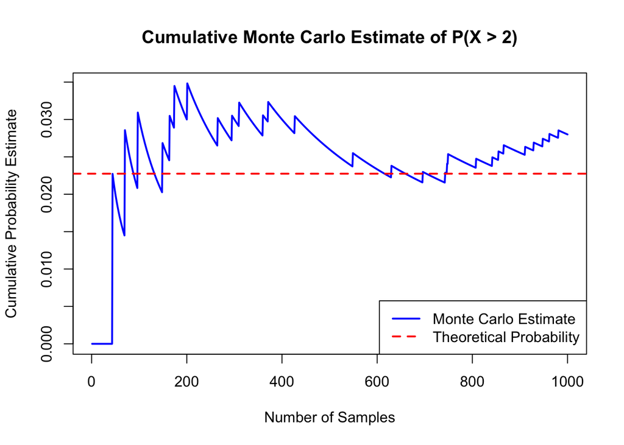

```r
# Plot the cumulative Monte Carlo estimates
plot(f_MC, type = "l", col = "blue", lwd = 2,
     xlab = "Number of Samples",
     ylab = "Cumulative Probability Estimate",
     main = "Cumulative Monte Carlo Estimate of P(X > 2)")

# Add a horizontal line at the theoretical probability
abline(h = pnorm(2, lower.tail = FALSE), col = "red", lwd = 2, lty = 2)

# Add a legend
legend("bottomright", legend = c("Monte Carlo Estimate", "Theoretical Probability"),
       col = c("blue", "red"), lwd = 2, lty = c(1, 2))
```

This plot differs from the one we saw in class in that it looks more jagged, and doesn’t seem to converge at the end. This is because we are using a relatively small number of samples (T = 1000), so the model doesn’t have enough time to converge.

### 1. (b) Importance Sampling

$$\begin{equation*}
\frac{1}{T}\sum_{t=1}^T{\frac{p\left(x_{IS}^{(t)} \right)
}{q\left(x_{IS}^{(t)}\right) } I\left(x_{IS}^{(t)}>2 \right) }
\end{equation*}$$

Lets apply this to calculating the probability that $X > 2$ given $X \sim N(0,1)$. Because we are interested in the probability $X > 2$, lets use a distribution that is closer to 2: $q=N(2,1)$. So, samples from the proposal distribution come from $N(2,1)$ (a normal distribution with a mean of 2 and variance of 1). This can be drawn from a standard normal distribution (N(0,1)) from by adding two to a random variable generated from standard normal distribution.

One way to solve the problem then is to sample each data point from $q$ and then use a function that returns the probability density of some value under a Normal distribution with a specified mean and variance. Alternatively, you could divide $p$ by $q$ explicitly. The explicit solution is
$$\begin{equation*}
\frac{1}{T}\sum_{t=1}^T{ e^{-2 x_{IS}^{(t)} +2 } I (x_{IS}^{(t)} >
2)}
\end{equation*}$$

Now, make the same plot as in 1a, but now using the importance sampling estimate (i.e., plot a vector ${\bf f}^{IS}$ such that $f_t^{IS}$ is the importance sampling estimate of the probability that a standard normal randomly generated variable is greater than 2 using $q \sim N(2,1)$ after $t$ samples). Write 1-2 sentences explaining why the plot of the updated importance sampling estimate looks the way it does. Also, please report the importance sampling estimate given all of the samples

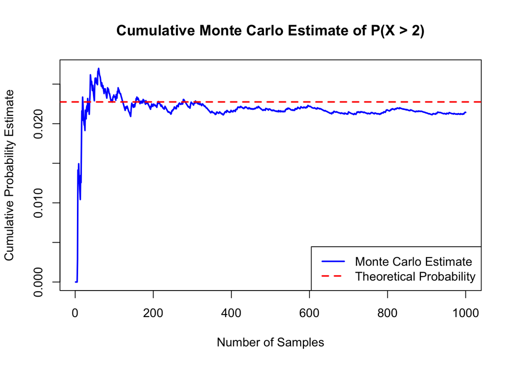

```r
mup <- 0
sdp <- 1
muq <- 2
sdq <- 1
Tee <- 1000


x_IS <- rnorm(Tee, mean = 0, sd = 1) + 2  # shift N(0, 1) by +2

f_IS <- numeric(Tee)

for (t in 1:Tee) {
    # calculate the density under the target distribution (p)
    p_values <- dnorm(x_IS[1:t], mean = 0, sd = 1)

    # Calculate the density under the proposal distribution (q)
    q_values <- dnorm(x_IS[1:t], mean = 2, sd = 1)

    # Compute the importance weights as the ratio of p(x) / q(x)
    weights <- p_values / q_values

    # Compute the indicator fn I(x > 2) for the first t samples
    indicator <- as.numeric(x_IS[1:t] > 2)

    # Calculate the importance sampling estimate as the mean of the weighted distribution
    f_IS[t] <- mean(weights * indicator)
}

# Plot the cumulative Monte Carlo estimates
plot(f_IS, type = "l", col = "blue", lwd = 2,
     xlab = "Number of Samples",
     ylab = "Cumulative Probability Estimate",
     main = "Cumulative Monte Carlo Estimate of P(X > 2)")

# Add a horizontal line at the theoretical probability
abline(h = pnorm(2, lower.tail = FALSE), col = "red", lwd = 2, lty = 2)

# Add a legend
legend("bottomright", legend = c("Monte Carlo Estimate", "Theoretical Probability"),
       col = c("blue", "red"), lwd = 2, lty = c(1, 2))
```

### Answer:

This plot looks much more like what we saw in class, less jagged and much closer to the theoretical probability. This is because importance sampling helps the model to converge more quickly.

### 1. (c) Compare and explain

Write a few sentences comparing Figures 1a and 1b: How and why do they differ? What is a broad lesson about Monte Carlo approximation that we can learn from this comparison?

### Answer:

The plots differ in the extent to which they converge on the theoretical probability after the 1000 samples. This shows the difference between naive monte carlo and importance sampling monte carlo–importance sampling helps to converge on the theoretical probability more quickly because it samples values that wouldn’t be sampled as often in naive monte carlo. Essentially, it helps us to get a better idea of the overall distribution by sampling a better spread of the values.

## 2 Markov chain Monte Carlo

$$\begin{align*}
\alpha \sim {\rm Exponential}(1) & & \beta \sim {\rm Beta}(1,1)
\\
\theta_i | \alpha, \beta \sim {\rm Beta}\left(\alpha \beta, \alpha
(1-\beta)\right) & & y_i | n_i, \theta_i \sim {\rm Binomial}
(\theta_i; n_i)
\end{align*}$$

*Tip: Most programming languages provide functions for generating Exponential and Beta distributed random variables.*

Remember their cover story. Imagine that you come across a box filled with bags of marbles. Each bag has a lot of marbles. Each marble is either black or white. You get to observe $n_i$ marbles from bag $i$ and write down that $y_i$ of them are white. The proportion of white marbles in bag $i$ is $\theta_i$ (and because there are lots and lots of marbles in each bag, we can safely assume that $y_i$ is Binomial distributed with parameters $\theta_i$ and $n_i$).

### 2a. Beta distributions

You can look up information about the Beta distribution on the Conjugate Prior page of Wikipedia.

*Note that the notation here follows the notation used by Kemp et al. (2007). Wikipedia uses a different notation, which is actually the more standard one in statistics.}.*

For each $\alpha$ and $\beta$ value, please graph: 1. the prior distribution, (i.e. , no marbles observed) the posterior after observing one white marble (and zero black marbles) 2. the posterior distribution after observing 5 white and 5 black marbles, 3. and the posterior distribution after observing 9 white and 1 black marble all on the same plot.

I provide the $a$ and $b$ values as well (which is usually what most programming languages expect) and correspond to the standard/Wikipedia parameterization of the Beta distribution).

### Please explore the following Beta distributions:

1. $\alpha = 0.1$ and $\beta = 0.5$ ($a=0.05, b=0.05$)
2. $\alpha = 0.1$ and $\beta = 0.9$ ($a=0.09, b = 0.01$)
3. $\alpha = 1$ and $\beta = 0.5$ ($a=0.5, b = 0.5$)
4. $\alpha = 1$ and $\beta = 0.9$ ($a = 0.9, b = 0.1$)
5. $\alpha = 5$ and $\beta = 0.5$ ($a = 2.5, b = 2.5$)
6. $\alpha = 5$ and $\beta = 0.9$ ($a=4.5, b = 0.5$)

Although I expect you to execute and think about each of these, you are only required to turn in one of the graphs. Please turn in make sure that the graph is visible and each distribution is distinct and clearly labelled. Please write a paragraph describing how changing $\alpha$ and $\beta$ affect the posterior update.

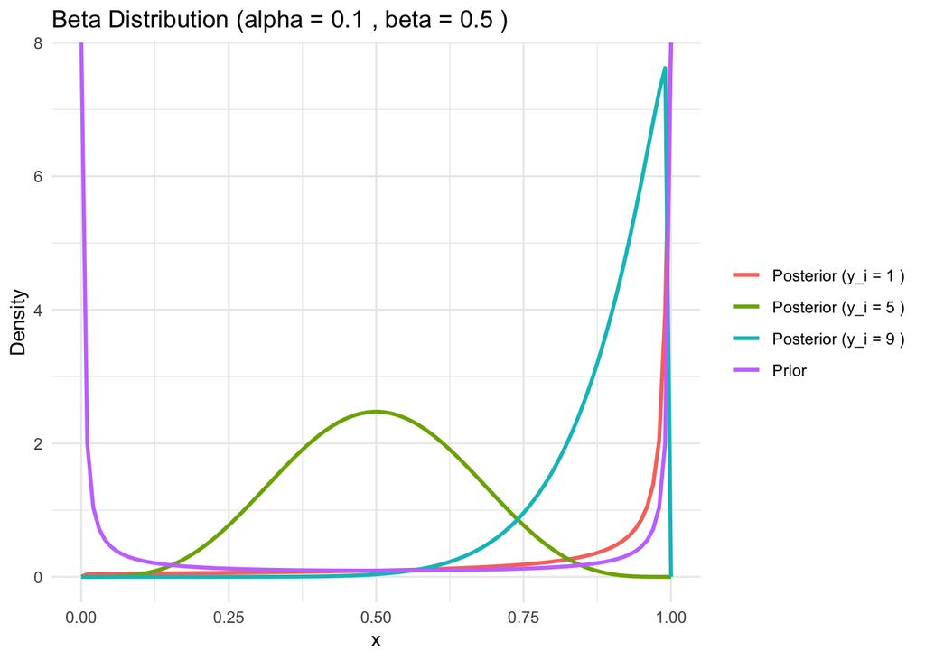

```r
# Define the posterior function
posterior <- function(alpha, beta, N, y_i) {
  post_beta <- c((alpha * beta + y_i), (alpha * (1 - beta) + (N - y_i)))
  return(post_beta)
}

# Function to plot the distributions
plot_distributions <- function(alpha, beta, yn_i, a, b) {
  # Generate x values
  x <- seq(0, 1, length.out = 100)

  # Calculate prior density
  prior_density <- dbeta(x, a, b)

  # Create a data frame for plotting
  df <- data.frame(x = x, density = prior_density, type = "Prior")

  # Calculate and add posterior densities
  for (i in 1:length(yn_i)) {
    y_i <- yn_i[[i]]
    y_i <- y_i[1]
    n_i <- yn_i[[i]]
    n_i <- n_i[2]
    post_params <- posterior(alpha, beta, n_i, y_i)
    post_density <- dbeta(x, post_params[1], post_params[2])
    df <- rbind(df, data.frame(x = x, density = post_density, type = paste("Posterior (y_i =", y_i, ")")))
  }
  # Plot the distributions
  ggplot(df, aes(x = x, y = density, color = type)) +
    geom_line(linewidth = 1) +
    labs(title = paste("Beta Distribution (alpha =", alpha, ", beta =", beta, ")"),
         x = "x", y = "Density") +
    theme_minimal() +
    theme(legend.title = element_blank())
}

yn_i <- list(c(1, 1), c(5, 10), c(9, 10))

plot_distributions(.1, .5, yn_i, .05, .05)
```

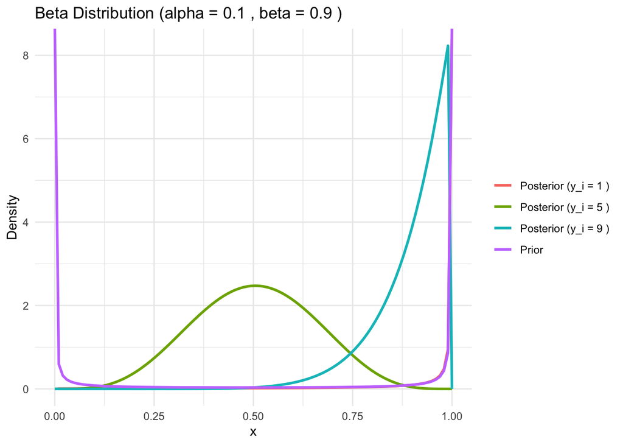

```r
plot_distributions(0.1, 0.9, yn_i, 0.09, 0.01)
```

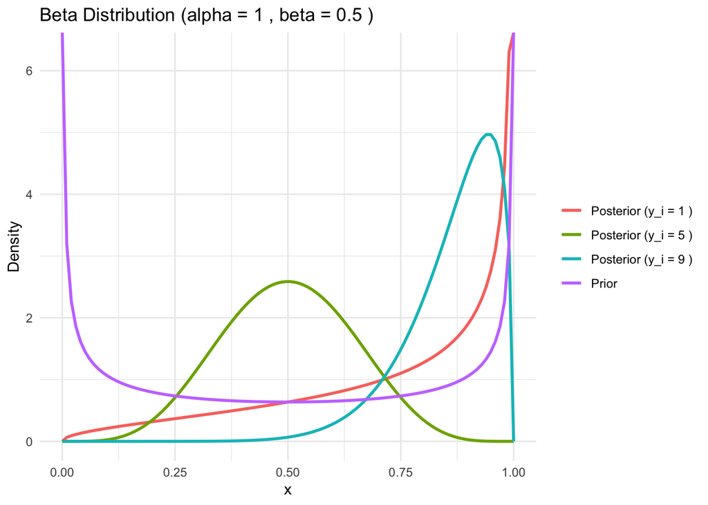

```r
plot_distributions(1, 0.5, yn_i, 0.5, 0.5)
```

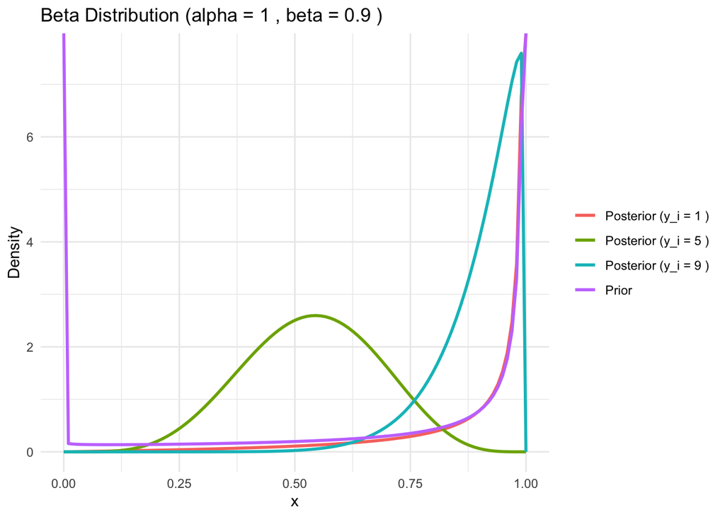

```r
plot_distributions(1, 0.9, yn_i, 0.9, 0.1)
```

### 2b. Implementing a MCMC sampler

Now you will implement samplers to estimate the posterior distribution on $\alpha$, $\beta$, and $\theta_1,\dotsc \theta_M$ after observing some marbles from $M$ bags (i.e., given $y_1, \dotsc, y_M,n_1,\dotsc,n_M$) and the predictive probability for the probability of white marbles in new bags after observing some marbles from some bags (i.e., given $y_1, \dotsc, y_M,n_1,\dotsc,n_M$). We will be approximating the posterior distribution of $\theta_1\dotsc,\theta_M$ using Gibbs sampling steps and interleaving these steps with Metropolis-Hastings Markov chain Monte Carlo (MH MCMC) sampling for $\alpha$ and $\beta$.

Here is an overview of the process:  
1. Initialize $\alpha$ and $\beta$ by sampling them from their priors (Exponential(1) and Beta(1,1), respectively). 2. Sample a value for each $\theta_m$ of the $M$ bags based on current $\alpha$ and $\beta$. 3. Sample new proposal values for $\alpha$ and $\beta$ given the $M$ sampled $\theta$ values via an equation provided in the detailed procedure below. 4. Accept the proposed $\alpha$ and $\beta$, or to keep the previous values. 5. Repeat from 2 until convergence

To implement the Gibbs sampling portion, we iterate through the bags and for each bag, we resample the current value for the proportion of white marbles in bag $i$ ($\theta_i^{(t)}$) given the value of all other variables (so, given $\theta_1^{(t-1)}, \dotsc, \theta_{i-1}^{(t-1)}, \dotsc$, $\theta_{i+1}^{(t-1)}, \dotsc, \theta_M^{(t-1)}, \alpha^{(t)}, \beta^{(t)}, {\bf y}, {\bf n}$). Given $\alpha$ and $\beta$ all of the bags are independent of each other (if you’re not sure, use the conditional independence rules for graphical models we discussed in class), and so, we sample $\theta_i^{(t)} | \alpha^{(t)}, \beta^{(t)}, y_i, n_i$. Fortunately, we already know this from the last subproblem! It’s a Beta-Binomial model and so

$$\begin{equation*}
\theta_i^{(t)} | \alpha^{(t)}, \beta^{(t)}, y_i, n_i \sim {\rm
Beta}\left( \alpha^{(t)} \beta^{(t)} + y_i, \alpha^{(t)}
(1-\beta^{(t)})+ (n_i-y_i) \right)
\end{equation*}$$

To implement MH MCMC, we first initialize the Markov chain by a random sample from the prior ($\alpha^{(1)} \sim {\rm Exponential}(1)$ and $\beta^{(1)} \sim {\rm Beta}(1,1)$) and then for $t =1,\dotsc, T$ follow the following steps:

1. Do a ``sweep’’ (resample each $\theta^{(t)}_i$ once) of Gibbs sampling. You should sample the $M$ bags in a random order each sweep.So, resample each $\theta_i$: $\theta_i^{(t)} | \alpha^{(t)}, \beta^{(t)}, y_i, n_i \sim {\rm Beta}\left( \alpha^{(t)} \beta ^{(t)}+ y_i, \alpha^{(t)} (1-\beta^{(t)})+ (n_i-y_i) \right)$
2. Generate a proposed next state for the sampler using the current state. To do so, sample $\alpha'$ by adding $X \sim {\rm Student's \ }t(1)$ to $\alpha^{(t)}$ and sample $\beta' | \beta^{(t)} \sim {\rm Beta}(1+\beta^{(t)}, 2-\beta^{(t)})$.
3. Calculate the probability $c$ that we accept $\alpha'$ and $\beta'$ as the next state. Because the proposal distribution for $\alpha$ is symmetric, we do not need to include it in our acceptance term. However, the proposal distribution for $\beta$ is not symmetric, and so the MH requires a correction term to ensure that the probability that we move back and forth between states. So, the acceptance probability is the product of two probabilities: (1) the ratio of the probability of transitioning from the proposal back to the current state to the probability of the reverse transition and (2) the ratio of the posterior probability of the proposal to the posterior probability of the previous sample. Don’t worry. I’ve done the derivation for you (it is straightforward, so it’s a good exercise to do if you are curious!). It is
   $$\begin{align*}
   c &= \frac{q(\beta^{(t)}|\beta') p(\alpha', \beta' |
   \theta_1^{(t)}, \dotsc, \theta_M^{(t)})}{q(\beta'|\beta^{(t)})
   p(\alpha^{(t)}, \beta^{(t)} | \theta_1^{(t)}, \dotsc, \theta_M^{(t)}) }
   \\
   &= \frac{ \texttt{betapdf}(\beta^{(t)}; 1+ \beta', 2-\beta')
   p(\alpha') p(\beta') \prod_{i}{p\left( \theta_i^{(t)} |
   \alpha', \beta' \right)}} { \texttt{betapdf}(\beta';
   1+\beta^{(t)},2-\beta^{(t)})
   p(\alpha^{(t)})p(\beta^{(t)})\prod_{i}{p\left( \theta_i^{(t)} |
   \alpha^{(t)}, \beta^{(t)} \right)}}
   \end{align*}$$
   where $\texttt{betapdf(x;y,z)}$ is the amount of density at $x$ given by a Beta function with parameters $y$ and $z$.
4. Sample $ Y U(0,1)$. If $Y \leq c$, $\left(\alpha^{(t+1)}, \beta^{(t+1)}\right) = (\alpha', \beta')$. Otherwise, reject and the next sample is the same as $t$: $\left(\alpha^{(t+1)}, \beta^{(t+1)}\right)=\left(\alpha^{(t)}, \beta^{(t)}\right)$

Now we use the sampler to explore the model’s behavior given different sets of marble bags. Please use the following sets of marble bags: 1. 10 bags where each bag has 9 white and 11 black marbles. 2. 5 bags with 1 white and 19 black marbles, and 5 bags with 19 white and 1 black marble.

For each of these, please run the sampler for 3000 sweeps ($T=3000$). Please include (two separate) histograms of the $\alpha$ samples and $\beta$ samples for both I. and II. Also, calculate the average $\alpha$ and $\beta$ value, and the expected value for a new bag of marbles ($\theta_{M+1}$) after observing the bags of marbles for each (note that this is $\frac{\bar{\alpha} \bar{\beta}}{\bar{\alpha} \bar{\beta}+ \bar{\alpha}(1- \bar{\beta})}$, where $\bar{\cdot}$ is the average of that variable).

```r
# First scenario: 10 bags with 9 white and 11 black marbles
y1 <- rep(9, 10)   # 9 white marbles in each bag
n1 <- rep(20, 10)  # total of 20 marbles per bag
M1 <- length(y1)   # number of bags

# Second scenario: 5 bags with 1 white and 19 black, and 5 bags with 19 white and 1 black
y2 <- c(rep(1, 5), rep(19, 5))  # 1 white for first 5 bags, 19 white for next 5
n2 <- rep(20, 10)                # total of 20 marbles per bag
M2 <- length(y2)                 # number of bags

# Initialize values
initialize_values <- function(M) {
  # Initialize alpha and beta from priors
  alpha <- rexp(1, rate = 1)
  beta <- rbeta(1, shape1 = 1, shape2 = 1)

  # Initialize each theta_i
  theta <- numeric(M)
  for (i in 1:M) {
    theta[i] <- rbeta(1, alpha * beta, alpha * (1 - beta))
  }

  return(list(alpha = alpha, beta = beta, theta = theta))
}

sampler <- function(y, n, iterations, burnin = 500) {
  M <- length(y)

  # Initialize values
  init <- initialize_values(M)
  alpha <- init$alpha
  beta <- init$beta
  theta <- init$theta

  # Vectors to store values
  alpha_samples <- numeric(iterations)
  beta_samples <- numeric(iterations)
  theta_samples <- matrix(0, nrow = iterations, ncol = M)

  # Store the initial values
  alpha_samples[1] <- alpha
  beta_samples[1] <- beta
  theta_samples[1, ] <- theta

  for (t in 2:iterations) {
    # Gibbs sampling for each theta_i (in random order)
    bag_order <- sample(1:M)
    for (i in bag_order) {
      # Posterior shape params
      shape1_post <- alpha * beta + y[i]
      shape2_post <- alpha * (1 - beta) + (n[i] - y[i])
      theta[i] <- rbeta(1, shape1_post, shape2_post)
    }

    # Metropolis-Hastings for Alpha
    proposal_alpha <- alpha + rt(1, df = 1)

    # Enforce alpha' > 0
    if (proposal_alpha <= 0) {
      proposal_alpha <- alpha
    }

    # Metropolis-Hastings for Beta
    # Fix: properly sample from Beta(1+beta, 2-beta)
    proposal_beta <- rbeta(1, 1 + beta, 2 - beta)

    # Compute q(beta_t|beta') for the correction term
    q_current_given_proposal <- dbeta(beta, 1 + proposal_beta, 2 - proposal_beta)

    # Compute q(beta'|beta_t) for the correction term
    q_proposal_given_current <- dbeta(proposal_beta, 1 + beta, 2 - beta)

    # Compute prior probabilities
    prior_current <- dexp(alpha, rate = 1) * dbeta(beta, 1, 1)
    prior_proposal <- dexp(proposal_alpha, rate = 1) * dbeta(proposal_beta, 1, 1)

    # Compute likelihoods
    likelihood_current <- 1
    likelihood_proposed <- 1

    for (i in 1:M) {
      likelihood_current <- likelihood_current * dbeta(theta[i], alpha * beta, alpha * (1 - beta))
      likelihood_proposed <- likelihood_proposed * dbeta(theta[i], proposal_alpha * proposal_beta,
                                                         proposal_alpha * (1 - proposal_beta))
      }

    # Compute the C ratio
    c_ratio <- (q_current_given_proposal / q_proposal_given_current) * (prior_proposal * likelihood_proposed) /
               (prior_current * likelihood_current)

    # Accept or reject proposal
    if (runif(1) < min(1, c_ratio)) {
      alpha <- proposal_alpha
      beta <- proposal_beta
    }

    # Store samples
    alpha_samples[t] <- alpha
    beta_samples[t] <- beta
    theta_samples[t, ] <- theta
  }

  # Discard burn-in samples
  if (burnin > 0 && burnin < iterations) {
    alpha_samples <- alpha_samples[(burnin+1):iterations]
    beta_samples <- beta_samples[(burnin+1):iterations]
    theta_samples <- theta_samples[(burnin+1):iterations, ]
  }

  # Return MCMC chain
  list(
    alpha = alpha_samples,
    beta = beta_samples,
    theta = theta_samples
  )
}
```

```r
# Run the sampler for both scenarios (3000 iterations with 500 burnin)
set.seed(123)  # For reproducibility
results1 <- sampler(y1, n1, 3500, 500)  # Scenario 1
results2 <- sampler(y2, n2, 3500, 500)  # Scenario 2

# Calculate summary statistics for scenario 1
alpha_mean1 <- mean(results1$alpha)
beta_mean1 <- mean(results1$beta)
expected_new_bag1 <- (alpha_mean1 * beta_mean1) /
                     (alpha_mean1 * beta_mean1 + alpha_mean1 * (1 - beta_mean1))

# Calculate summary statistics for scenario 2
alpha_mean2 <- mean(results2$alpha)
beta_mean2 <- mean(results2$beta)
expected_new_bag2 <- (alpha_mean2 * beta_mean2) /
                     (alpha_mean2 * beta_mean2 + alpha_mean2 * (1 - beta_mean2))

# Print summary statistics
cat("Scenario 1 (10 bags with 9 white and 11 black marbles):\n")
```

```
## Scenario 1 (10 bags with 9 white and 11 black marbles):
```

```r
cat("Average alpha:", alpha_mean1, "\n")
```

```
## Average alpha: 5.27611
```

```r
cat("Average beta:", beta_mean1, "\n")
```

```
## Average beta: 0.4609002
```

```r
cat("Expected probability of white marble in new bag:", expected_new_bag1, "\n\n")
```

```
## Expected probability of white marble in new bag: 0.4609002
```

```r
cat("Scenario 2 (5 bags with 1 white, 5 bags with 19 white):\n")
```

```
## Scenario 2 (5 bags with 1 white, 5 bags with 19 white):
```

```r
cat("Average alpha:", alpha_mean2, "\n")
```

```
## Average alpha: 0.8449755
```

```r
cat("Average beta:", beta_mean2, "\n")
```

```
## Average beta: 0.497554
```

```r
cat("Expected probability of white marble in new bag:", expected_new_bag2, "\n")
```

```
## Expected probability of white marble in new bag: 0.497554
```

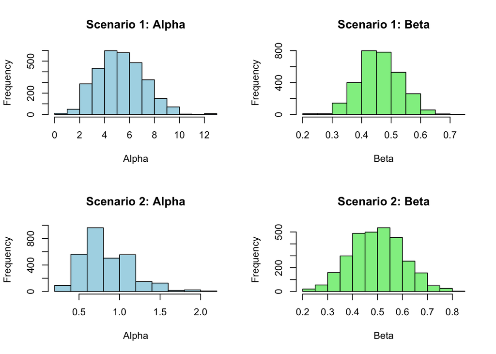

```r
# Plotting histograms
par(mfrow = c(2, 2))

# Scenario 1 histograms
hist(results1$alpha, main = "Scenario 1: Alpha", xlab = "Alpha", col = "lightblue")
hist(results1$beta, main = "Scenario 1: Beta", xlab = "Beta", col = "lightgreen")

# Scenario 2 histograms
hist(results2$alpha, main = "Scenario 2: Alpha", xlab = "Alpha", col = "lightblue")
hist(results2$beta, main = "Scenario 2: Beta", xlab = "Beta", col = "lightgreen")
```

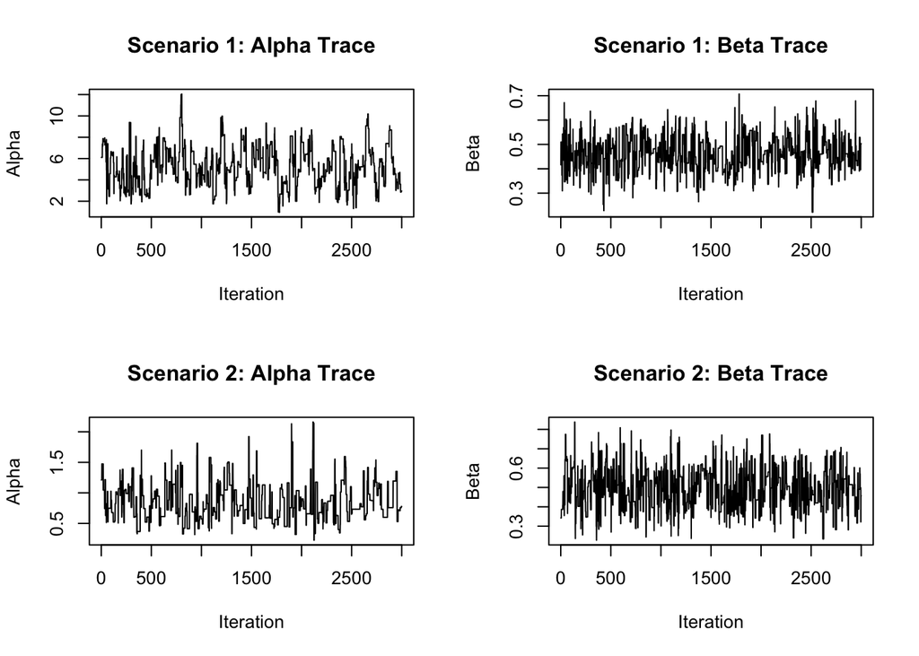

```r
# Additional analysis: Trace plots to check convergence
par(mfrow = c(2, 2))

# Scenario 1 trace plots
plot(results1$alpha, type = "l", main = "Scenario 1: Alpha Trace",
     xlab = "Iteration", ylab = "Alpha")
plot(results1$beta, type = "l", main = "Scenario 1: Beta Trace",
     xlab = "Iteration", ylab = "Beta")

# Scenario 2 trace plots
plot(results2$alpha, type = "l", main = "Scenario 2: Alpha Trace",
     xlab = "Iteration", ylab = "Alpha")
plot(results2$beta, type = "l", main = "Scenario 2: Beta Trace",
     xlab = "Iteration", ylab = "Beta")
```

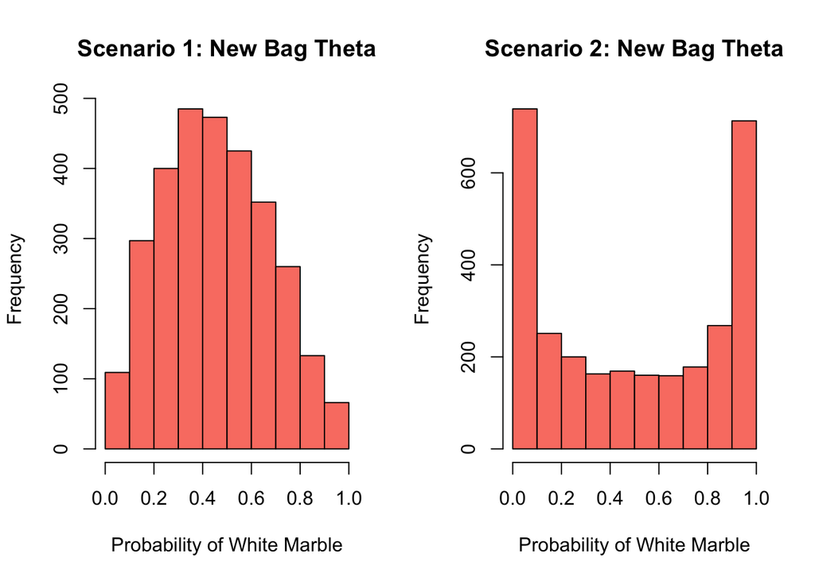

```r
# Posterior predictive distribution for new bags
par(mfrow = c(1, 2))

# Calculate posterior predictive for Scenario 1
theta_new_samples1 <- numeric(length(results1$alpha))
for (i in 1:length(results1$alpha)) {
  theta_new_samples1[i] <- rbeta(1,
                               results1$alpha[i] * results1$beta[i],
                               results1$alpha[i] * (1 - results1$beta[i]))
}

# Calculate posterior predictive for Scenario 2
theta_new_samples2 <- numeric(length(results2$alpha))
for (i in 1:length(results2$alpha)) {
  theta_new_samples2[i] <- rbeta(1,
                               results2$alpha[i] * results2$beta[i],
                               results2$alpha[i] * (1 - results2$beta[i]))
}

# Plot posterior predictive distributions
hist(theta_new_samples1, main = "Scenario 1: New Bag Theta",
     xlab = "Probability of White Marble", col = "salmon")
hist(theta_new_samples2, main = "Scenario 2: New Bag Theta",
     xlab = "Probability of White Marble", col = "salmon")
```

Please write two paragraphs. In the first paragraph, describe the histograms for $\alpha$ and $\beta$ given each set of marble bags and explain what their values mean. In the second paragraph, compare the histograms and the values you were asked to calculate. What is equal and unequal? Explain why.